# Case Study 2: IMDB – Binary Classification of Movie Reviews

In this case study, our objective is to classify movie reviews as positive or negative. This is a classic *binary classification*, which aims to predict one of two classes (*positive vs. negative*). To predict whether a review is positive or negative, we will use the text of the movie review. [ℹ️](http://bit.ly/dl-02#21)

Throughout this case study you will learn a few new concepts:

- Vectorizing text with one-hot encoding
- Regularization with:
  - Learning rate
  - Model capacity
  - Weight decay
  - Dropout

# Package requirements

```r
library(keras)     # for deep learning
library(tidyverse) # for dplyr, ggplot2, etc.
library(testthat)  # unit testing
library(glue)      # easy print statements
```

# The IMDB dataset

Our data consists of 50,000 movie reviews from [IMDB](https://www.imdb.com/). This data has been curated and supplied to us via keras; however, tomorrow we will go through the process of preprocessing the original data on our own. First, let’s grab our data and unpack them into training vs test and features vs labels.

```r
imdb <- dataset_imdb(num_words = 10000)
c(c(reviews_train, y_train), c(reviews_test, y_test)) %<-% imdb

length(reviews_train)   # 25K reviews in our training data
```

```
[1] 25000
```

```r
length(reviews_test)    # 25K reviews in our test data
```

```
[1] 25000
```

# Understanding our data

1. start of a sequence
2. unknown words
3. padding

the integer “14” represents the $14 - 3 = 11$th most frequent word.

```r
reviews_train[[1]]
```

```
  [1]    1   14   22   16   43  530  973 1622 1385   65  458 4468   66 3941    4  173
 [17]   36  256    5   25  100   43  838  112   50  670    2    9   35  480  284    5
 [33]  150    4  172  112  167    2  336  385   39    4  172 4536 1111   17  546   38
 [49]   13  447    4  192   50   16    6  147 2025   19   14   22    4 1920 4613  469
 [65]    4   22   71   87   12   16   43  530   38   76   15   13 1247    4   22   17
 [81]  515   17   12   16  626   18    2    5   62  386   12    8  316    8  106    5
 [97]    4 2223 5244   16  480   66 3785   33    4  130   12   16   38  619    5   25
[113]  124   51   36  135   48   25 1415   33    6   22   12  215   28   77   52    5
[129]   14  407   16   82    2    8    4  107  117 5952   15  256    4    2    7 3766
[145]    5  723   36   71   43  530  476   26  400  317   46    7    4    2 1029   13
[161]  104   88    4  381   15  297   98   32 2071   56   26  141    6  194 7486   18
[177]    4  226   22   21  134  476   26  480    5  144   30 5535   18   51   36   28
[193]  224   92   25  104    4  226   65   16   38 1334   88   12   16  283    5   16
[209] 4472  113  103   32   15   16 5345   19  178   32
```

We can map the integer values back to the original word index (`dataset_imdb_word_index()`). The integer number corresponds to the position in the word count list and the name of the vector is the actual word.

```r
word_index <- dataset_imdb_word_index() %>%
  unlist() %>%
  sort() %>%
  names()

# The indices are offset by 3 since 0, 1, and 2 are reserved for "padding",
# "start of sequence", and "unknown"
reviews_train[[1]] %>%
  map_chr(~ ifelse(.x >= 3, word_index[.x - 3], "<UNK>")) %>%
  cat()
```

```
<UNK> this film was just brilliant casting location scenery story direction everyone's really suited the part they played and you could just imagine being there robert <UNK> is an amazing actor and now the same being director <UNK> father came from the same scottish island as myself so i loved the f…
```

Our response variable is just a vector of 1s (positive reviews) and 0s (negative reviews).

```r
str(y_train)
```

```
 int [1:25000] 1 0 0 1 0 0 1 0 1 0 ...
```

```r
# our labels are equally balanced between positive (1s) and negative (0s)
# reviews
table(y_train)
```

```
y_train
    0     1
12500 12500
```

# Preparing the features

All inputs and response values in a neural network must be tensors of either floating-point or integer data. Moreover, our feature values should not be relatively large compared to the randomized initial weights *and* all our features should take values in roughly the same range.

Consequently, we need to *vectorize* our data into a format conducive to neural networks. For this data set, we’ll transform our list of article reviews to a 2D tensor of 0s and 1s representing if the word was used (aka one-hot encode). [ℹ️](http://bit.ly/dl-02#22)

```r
# number of unique words will be the number of features
n_features <- c(reviews_train, reviews_test) %>%
  unlist() %>%
  max()

# function to create 2D tensor (aka matrix)
vectorize_sequences <- function(sequences, dimension = n_features) {
  # Create a matrix of 0s
  results <- matrix(0, nrow = length(sequences), ncol = dimension)

  # Populate the matrix with 1s
  for (i in seq_along(sequences))
    results[i, sequences[[i]]] <- 1
  results
}

# apply to training and test data
x_train <- vectorize_sequences(reviews_train)
x_test <- vectorize_sequences(reviews_test)

# unit testing to make sure certain attributes hold
expect_equal(ncol(x_train), n_features)
expect_equal(nrow(x_train), length(reviews_train))
expect_equal(nrow(x_test), length(reviews_test))
```

Our transformed feature set is now just a matrix (2D tensor) with 25K rows and 10K columns (features).

```r
dim(x_train)
```

```
[1] 25000  9999
```

Let’s check out the first 10 rows and columns:

```r
x_train[1:10, 1:10]
```

```
      [,1] [,2] [,3] [,4] [,5] [,6] [,7] [,8] [,9] [,10]
 [1,]    1    1    0    1    1    1    1    1    1     0
 [2,]    1    1    0    1    1    1    1    1    1     0
 [3,]    1    1    0    1    0    1    1    1    1     0
 [4,]    1    1    0    1    1    1    1    1    1     1
 [5,]    1    1    0    1    1    1    1    1    0     1
 [6,]    1    1    0    1    0    0    0    1    0     1
 [7,]    1    1    0    1    1    1    1    1    1     0
 [8,]    1    1    0    1    0    1    1    1    1     1
 [9,]    1    1    0    1    1    1    1    1    1     0
[10,]    1    1    0    1    1    1    1    1    1     1
```

# Preparing the labels

In contrast to MNIST, the labels of a binary classification will just be one of two values, 0 (negative) or 1 (positive). We do not need to do any further preprocessing.

```r
str(y_train)
```

```
 int [1:25000] 1 0 0 1 0 0 1 0 1 0 ...
```

# Initial model

Since we are performing binary classification, our output activation function will be the *sigmoid activation function* [ℹ️](http://bit.ly/dl-01#44). Recall hat the sigmoid activation is used to predict the probability of the output being positive. This will constrain our output to be values ranging from 0-100%.

```r
network <- keras_model_sequential() %>%
  layer_dense(units = 16, activation = "relu", input_shape = n_features) %>%
  layer_dense(units = 16, activation = "relu") %>%
  layer_dense(units = 1, activation = "sigmoid")
```

```r
summary(network)
```

```
Model: "sequential"
_________________________________________________________________________________________
Layer (type)                            Output Shape                       Param #
=========================================================================================
dense (Dense)                           (None, 16)                         160000
_________________________________________________________________________________________
dense_1 (Dense)                         (None, 16)                         272
_________________________________________________________________________________________
dense_2 (Dense)                         (None, 1)                          17
=========================================================================================
Total params: 160,289
Trainable params: 160,289
Non-trainable params: 0
_________________________________________________________________________________________
```

We’re going to use *binary crossentropy* since we only have two possible classes.

```r
network %>% compile(
  optimizer = "rmsprop",
  loss = "binary_crossentropy",
  metrics = "accuracy"
)
```

Now let’s train our network for 20 epochs and we’ll use a batch size of 512 because, as you’ll find out, this model overfits very quickly (remember, large batch sizes compute more accurate gradient descents that traverse the loss more slowly).

```r
history <- network %>% fit(
  x_train,
  y_train,
  epochs = 20,
  batch_size = 512,
  validation_split = 0.2
)
```

Check out our initial resuls:

```r
best_epoch <- which.min(history$metrics$val_loss)
best_loss <- history$metrics$val_loss[best_epoch] %>% round(3)
best_acc <- history$metrics$val_accuracy[best_epoch] %>% round(3)

glue("Our optimal loss is {best_loss} with an accuracy of {best_acc*100}%")
```

```
Our optimal loss is 0.27 with an accuracy of 89.6%
```

In the previous module, we had the problem of underfitting; however looking at our learning curve for this model it’s obvious that we have an overfitting problem.

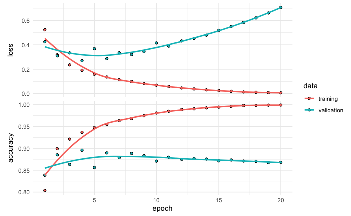

```r
plot(history)
```

## YOUR TURN (3 min)

Using what you learned in the last module, make modifications to this model such as:

1. Increasing or decreasing number of units and layers
2. Adjusting the learning rate
3. Adjusting the batch size
4. Adding callbacks (i.e. early stopping, learning rate adjuster)

```r
network <- keras_model_sequential() %>%
  layer_dense(units = ____, activation = "relu", input_shape = n_features) %>%
  layer_dense(units = ____, activation = "relu") %>%
  layer_dense(units = 1, activation = "sigmoid")

network %>% compile(
  optimizer = ____,
  loss = "binary_crossentropy",
  metrics = c("accuracy")
)

history <- network %>% fit(
  x_train,
  y_train,
  epochs = 20,
  batch_size = ____,
  validation_split = 0.2
)
```

Regardless of what you tried above, you likely had results that consistently overfit. Our quest is to see if we can control this overfitting. Often, when we control the overfitting we improve model performance and generalizability. To reduce overfitting we are going to look at a few common ways to *regularize* our model.

# Regularizing how quickly the model learns

Recall that the learning rate decides how fast we try to traverse the gradient descent of the loss. When the loss curve has a sharp U shape, this can indicate that your learning rate is too large.

The default learning rate for RMSprop is 0.001 (`?optimizer_rmsprop()`). Reducing the learning rate will allow us to traverse the gradient more cautiously. Although the learning rate is not traditionally considered a “regularization” hyperparameter, it should be the first hyperparameter you start assessing.

Best practice:

- When tuning the learning rate, we often try factors of $10^{-s}$ where s ranges between 1-6 (0.1, 0.01, …, 0.000001).
- Add `callback_reduce_lr_on_plateau()` to automatically adjust the learning during training.
- As you reduce the learning rate, reduce the batch size
  - Adds stochastic nature to reduce chance of getting stuck in local minimum
  - Speeds up training (small learning rate + large batch size = SLOW!)

```r
network <- keras_model_sequential() %>%
  layer_dense(units = 16, activation = "relu", input_shape = n_features) %>%
  layer_dense(units = 16, activation = "relu") %>%
  layer_dense(units = 1, activation = "sigmoid")

network %>% compile(
  optimizer = optimizer_rmsprop(lr = 0.0001),        # regularization parameter
  loss = "binary_crossentropy",
  metrics = c("accuracy")
)

history <- network %>% fit(
  x_train,
  y_train,
  epochs = 25,
  batch_size = 128,
  validation_split = 0.2,
  callbacks = list(
    callback_reduce_lr_on_plateau(patience = 3),     # regularization parameter
    callback_early_stopping(patience = 7)
  )
)
```

Our results show decrease in overfitting and improvement in our loss score and (possibly) accuracy.

```r
best_epoch <- which.min(history$metrics$val_loss)
best_loss <- history$metrics$val_loss[best_epoch] %>% round(3)
best_acc <- history$metrics$val_accuracy[best_epoch] %>% round(3)

glue("Our optimal loss is {best_loss} with an accuracy of {best_acc}")
```

```
Our optimal loss is 0.265 with an accuracy of 0.894
```

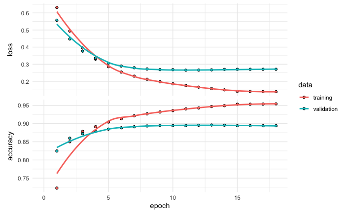

```r
plot(history) +
  scale_x_continuous(limits = c(0, length(history$metrics$val_loss)))
```

# Regularizing model capacity

In the last module, we discussed how we could add model capacity by increasing the number of units in each hidden layer and/or the number of layers to reduce underfitting. We can also reduce these parameters to regularize model capacity.

In the last module, we changed model capacity manually. Here, we’ll use a custom function and a `for` loop to automate this process.

## Variant 1: Larger or smaller layers?

Here, we’ll use a larger range of neurons (from $2^2 = 4$ to $2^8 = 256$) in each hidden layer.

To do this, we’ll define a function `dl_model` that allows us to define and compile our DL network with the specified number of neurons based on $2^n$. This function returns a data frame with the training and validation loss and accuracy for each epoch and number of neurons:

```r
dl_model <- function(powerto = 6) {

  network <- keras_model_sequential() %>%
    layer_dense(units = 2^powerto, activation = "relu",     # regularizing param
                input_shape = n_features) %>%
    layer_dense(units = 2^powerto, activation = "relu") %>% # regularizing param
    layer_dense(units = 1, activation = "sigmoid")

  network %>% compile(
      optimizer = "rmsprop",
      loss = "binary_crossentropy",
      metrics = c("accuracy")
      )

  history <- network %>%
    fit(
      x_train,
      y_train,
      epochs = 20,
      batch_size = 512,
      validation_split = 0.2,
      verbose = FALSE,
      callbacks = callback_early_stopping(patience = 5)
    )

  output <- as.data.frame(history) %>%
    mutate(neurons = 2^powerto)

  return(output)
  }
```

Let’s also define a helper function that simply pulls out the minimum loss score from the above output (this is not necessary, just informational):

```r
get_min_loss <- function(output) {
  output %>%
    filter(data == "validation", metric == "loss") %>%
    summarize(min_loss = min(value, na.rm = TRUE)) %>%
    pull(min_loss) %>%
    round(3)
}
```

Now we can iterate over $2^2 = 4$ to $2^8 = 256$ neurons in each layer:

```r
# so that we can store results
results <- data.frame()
powerto_range <- 2:8

for (i in powerto_range) {
  cat("Running model with", 2^i, "neurons per hidden layer: ")
  m <- dl_model(i)
  results <- rbind(results, m)
  loss <- get_min_loss(m)
  cat(loss, "\n", append = TRUE)
}
```

```
Running model with 4 neurons per hidden layer: 0.271
Running model with 8 neurons per hidden layer: 0.271
Running model with 16 neurons per hidden layer: 0.282
Running model with 32 neurons per hidden layer: 0.301
Running model with 64 neurons per hidden layer: 0.268
Running model with 128 neurons per hidden layer: 0.293
Running model with 256 neurons per hidden layer: 0.277
```

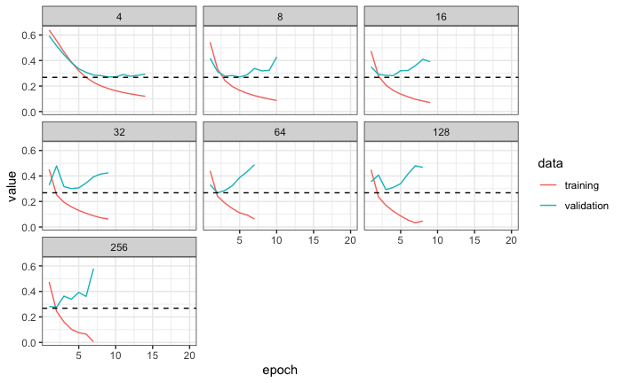

```r
min_loss <- results %>%
  filter(metric == "loss" & data == "validation") %>%
  summarize(min_loss = min(value, na.rm = TRUE)) %>%
  pull()

results %>%
  filter(metric == "loss") %>%
  ggplot(aes(epoch, value, color = data)) +
  geom_line() +
  geom_hline(yintercept = min_loss, lty = "dashed") +
  facet_wrap(~ neurons) +
  theme_bw()
```

## Variant 2: More or less layers?

We can perform a similar approach to assess the impact that the number of layers has on model performance. The following modifies our `dl_model` so that we can dynamically alter the number of layers and neurons.

```r
dl_model <- function(nlayers = 2, powerto = 4) {

  # Create a model with a single hidden input layer
  network <- keras_model_sequential() %>%
    layer_dense(units = 2^powerto, activation = "relu", input_shape = n_features)

  # regularizing parameter --> Add additional hidden layers based on input
  if (nlayers > 1) {
    for (i in seq_along(nlayers - 1)) {
      network %>% layer_dense(units = 2^powerto, activation = "relu")
    }
  }

  # Add final output layer
  network %>% layer_dense(units = 1, activation = "sigmoid")

  # Add compile step
  network %>% compile(
      optimizer = "rmsprop",
      loss = "binary_crossentropy",
      metrics = c("accuracy")
      )

  # Train model
  history <- network %>%
    fit(
      x_train,
      y_train,
      epochs = 25,
      batch_size = 512,
      validation_split = 0.2,
      verbose = FALSE,
      callbacks = callback_early_stopping(patience = 5)
    )

  # Create formated output for downstream plotting & analysis
  output <- as.data.frame(history) %>%
    mutate(nlayers = nlayers, neurons = 2^powerto)

  return(output)
  }
```

```r
# so that we can store results
results <- data.frame()
nlayers <- 1:6

for (i in nlayers) {
  cat("Running model with", i, "hidden layer(s) and 16 neurons per layer: ")
  m <- dl_model(nlayers = i, powerto = 4)
  results <- rbind(results, m)
  loss <- get_min_loss(m)
  cat(loss, "\n", append = TRUE)
}
```

```
Running model with 1 hidden layer(s) and 16 neurons per layer: 0.27
Running model with 2 hidden layer(s) and 16 neurons per layer: 0.274
Running model with 3 hidden layer(s) and 16 neurons per layer: 0.27
Running model with 4 hidden layer(s) and 16 neurons per layer: 0.278
Running model with 5 hidden layer(s) and 16 neurons per layer: 0.279
Running model with 6 hidden layer(s) and 16 neurons per layer: 0.274
```

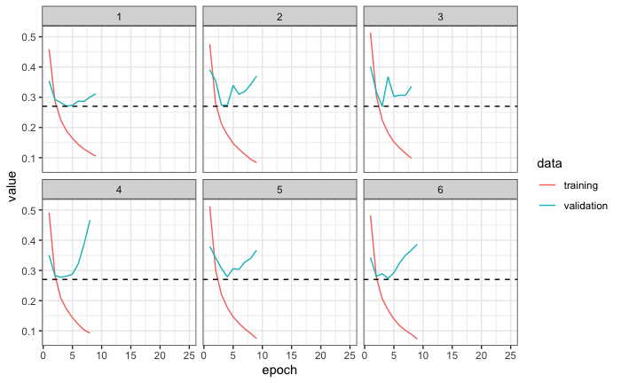

```r
min_loss <- results %>%
  filter(metric == "loss" & data == "validation") %>%
  summarize(min_loss = min(value, na.rm = TRUE)) %>%
  pull()

results %>%
  filter(metric == "loss") %>%
  ggplot(aes(epoch, value, color = data)) +
  geom_line() +
  geom_hline(yintercept = min_loss, lty = "dashed") +
  facet_wrap(~ nlayers, ncol = 3) +
  theme_bw()
```

# Regularizing the size of weights

A common way to mitigate overfitting is to put constraints on the complexity of a network by forcing its weights to take on small values, which makes the distribution of weight values more regular. This is called *weight regularization* and its done by adding to the loss function of the network a cost associated with having large weights.

If you a familiar with regularized regression [ℹ️](http://bit.ly/homlr-regularize) (lasso, ridge, elastic nets) then weight regularization is essentially the same thing. [ℹ️](http://bit.ly/dl-02#23)

Best practice:

- Although you can use L1, L2 or a combination, L2 is by far the most common and is known as *weight decay* in the context of neural nets.
- Optimal values vary but when tuning we typically start with factors of $10^{-s}$ where s ranges between 1-4 (0.1, 0.01, …, 0.0001).
- The larger the weight regularizer, the more epochs generally required to reach a minimum loss
- Weight decay can cause a noisier learning curve so its often beneficial to increase the `patience` parameter for early stopping

```r
network <- keras_model_sequential() %>%
  layer_dense(
    units = 16, activation = "relu", input_shape = n_features,
    kernel_regularizer = regularizer_l2(l = 0.01)    # regularization parameter
    ) %>%
  layer_dense(
    units = 16, activation = "relu",
    kernel_regularizer = regularizer_l2(l = 0.01)    # regularization parameter
    ) %>%
  layer_dense(units = 1, activation = "sigmoid")

network %>% compile(
    optimizer = "rmsprop",
    loss = loss_binary_crossentropy,
    metrics = c("accuracy")
)

history <- network %>% fit(
    x_train,
    y_train,
    epochs = 100,
    batch_size = 512,
    validation_split = 0.2,
    callbacks = callback_early_stopping(patience = 15)
)
```

Unfortunately, in this example, weight decay negatively impacts performance. The impact of weight decay is largely problem and data specific.

```r
best_epoch <- which.min(history$metrics$val_loss)
best_loss <- history$metrics$val_loss[best_epoch] %>% round(3)
best_acc <- history$metrics$val_accuracy[best_epoch] %>% round(3)

glue("Our optimal loss is {best_loss} with an accuracy of {best_acc}")
```

```
Our optimal loss is 0.375 with an accuracy of 0.885
```

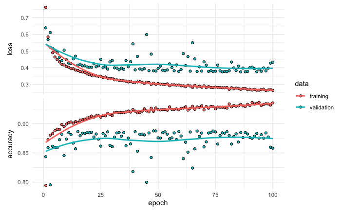

```r
plot(history) +
  scale_x_continuous(limits = c(0, length(history$metrics$val_loss)))
```

# Regularizing happenstance patterns

*Dropout* is one of the most effective and commonly used regularization techniques for neural networks. Dropout applied to a layer randomly drops out (sets to zero) a certain percentage of the output features of that layer. By randomly dropping some of a layer’s outputs we minimize the chance of fitting patterns to noise in the data, a common cause of overfitting. [ℹ️](http://bit.ly/dl-02#25)

Best practice:

- Dropout rates typically ranges between 0.2-0.5. Sometimes higher rates are necessary but note that you will get a warning when supplying rate > 0.5.
- The higher the dropout rate, the slower the convergence so you may need to increase the number of epochs.
- Its common to apply dropout after each hidden layer and with the same rate; however, this is not necessary.

```r
network <- keras_model_sequential() %>%
  layer_dense(units = 16, activation = "relu", input_shape = n_features) %>%
  layer_dropout(0.6) %>%                            # regularization parameter
  layer_dense(units = 16, activation = "relu") %>%
  layer_dropout(0.6) %>%                            # regularization parameter
  layer_dense(units = 1, activation = "sigmoid")

network %>% compile(
    optimizer = "rmsprop",
    loss = loss_binary_crossentropy,
    metrics = c("accuracy")
)

history <- network %>% fit(
    x_train,
    y_train,
    epochs = 100,
    batch_size = 512,
    validation_split = 0.2,
    callbacks = callback_early_stopping(patience = 10)
)
```

Similar to weight regularization, the impact of dropout is largely problem and data specific. In this example we do not see significant improvement.

```r
best_epoch <- which.min(history$metrics$val_loss)
best_loss <- history$metrics$val_loss[best_epoch] %>% round(3)
best_acc <- history$metrics$val_accuracy[best_epoch] %>% round(3)

glue("Our optimal loss is {best_loss} with an accuracy of {best_acc}")
```

```
Our optimal loss is 0.274 with an accuracy of 0.896
```

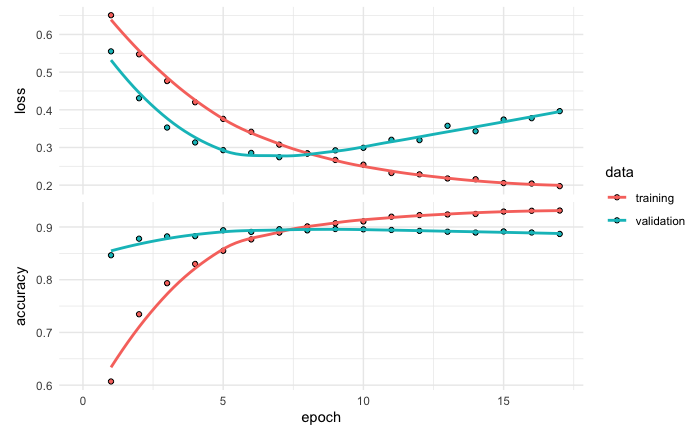

```r
plot(history) +
  scale_x_continuous(limits = c(0, length(history$metrics$val_loss)))
```

# So which is best?

There is no definitive best approach for minimizing overfitting. However, typically you want to focus first on finding the optimal learning rate and model capacity that optimizes the loss score. Then move on to fighting overfitting with dropout or weight decay.

Unfortunately, many of these hyperparameters interact so changing one can impact the performance of another. Performing a grid search can help you identify the optimal combination; however, as your data gets larger or as you start using more complex models such as CNNs and LSTMs, you often constrained by compute to adequately execute a sizable grid search. Here is a great paper on how to practically approach hyperparameter tuning for neural networks (https://arxiv.org/abs/1803.09820).

To see the performance of a grid search on this data set and the parameters discussed here, check out [this notebook](https://rstudio-conf-2020.github.io/dl-keras-tf/notebooks/imdb-grid-search.nb.html).

# Key takeaways

- Preparing text data
  - Text data is usually stored as numeric data representing a word index
  - We typically apply a word limit (i.e. top 10K, 20K, etc most frequent words)
  - In this example we one-hot encoded the features into a 2D tensor but tomorrow we will look at better approaches
- When our model overfits regularizing can improve model performance
- Common approaches to regularization
  - learning rate
  - model capacity
  - weight decay
  - dropout